# The Low FODMAP Diet: A Scientific Review of Efficacy, Mechanisms, and Clinical Considerations

Peter Hagen

2026-03-14

# 1 Abstract

Fermentable Oligosaccharides, Disaccharides, Monosaccharides, and Polyols (FODMAPs) represent a group of short-chain carbohydrates that are poorly absorbed in the small intestine and rapidly fermented by colonic bacteria. The low FODMAP diet has emerged as a first-line dietary therapy for Irritable Bowel Syndrome (IBS), with randomized controlled trials demonstrating symptom improvement in 50–80% of patients. However, the diet carries non-trivial risks including nutritional inadequacy, adverse shifts in the gut microbiome, disordered eating patterns, and reduced quality of life during the elimination phase. This document provides a rigorous, evidence-based analysis of the diet’s mechanisms, clinical benefits, limitations, and the critical importance of the three-phase protocol under dietitian supervision.

# 2 Introduction

## 2.1 The FODMAP Hypothesis

The FODMAP concept was first formalized by researchers at Monash University (Melbourne, Australia) in 2005, when Peter Gibson and Susan Shepherd proposed that a collective reduction in dietary short-chain fermentable carbohydrates—rather than elimination of a single sugar—could alleviate functional gastrointestinal (GI) symptoms. The hypothesis rests on three physiological pillars:

1. **Osmotic activity**: Unabsorbed small molecules draw water into the intestinal lumen via osmosis, increasing luminal distension.
2. **Rapid fermentation**: Colonic bacteria ferment these substrates, producing hydrogen (H₂), methane (CH₄), and carbon dioxide (CO₂), leading to gas-mediated distension.
3. **Visceral hypersensitivity**: In patients with IBS, normal or mildly elevated luminal distension triggers disproportionate pain signaling through sensitized afferent nerve pathways.

Table 1. FODMAP Categories, Food Sources, and Malabsorption Mechanisms

| Category | Subtype | Key Food Sources | Mechanism of Malabsorption |
| --- | --- | --- | --- |
| Oligosaccharides | Fructans | Wheat, rye, onion, garlic, artichoke, inulin | Humans lack inulinase; no small intestinal hydrolysis |
|  | Galacto-oligosaccharides (GOS) | Legumes, lentils, chickpeas, cashews, pistachios | Humans lack α-galactosidase; no small intestinal hydrolysis |
| Disaccharides | Lactose | Milk, soft cheeses, yogurt, ice cream | Lactase deficiency (primary or secondary hypolactasia) |
| Monosaccharides | Excess Fructose | Apples, pears, mango, honey, agave, HFCS | Fructose absorption capacity exceeded when fructose > glucose |
| Polyols | Sorbitol | Apples, pears, stone fruits, sugar-free gum | Passive diffusion via slow, concentration-dependent transport |
|  | Mannitol | Mushrooms, cauliflower, sugar-free confectionery | Passive diffusion via slow, concentration-dependent transport |

## 2.2 Epidemiological Context

IBS affects an estimated 10–15% of the global population, with a 2:1 female-to-male prevalence ratio. The Rome IV criteria classify IBS into subtypes based on predominant stool pattern: IBS-D (diarrhea-predominant), IBS-C (constipation-predominant), IBS-M (mixed), and IBS-U (unsubtyped). The economic burden is substantial—direct healthcare costs in the United States alone exceed $1.5 billion annually, with indirect costs (absenteeism, presenteeism) estimated at $20 billion.

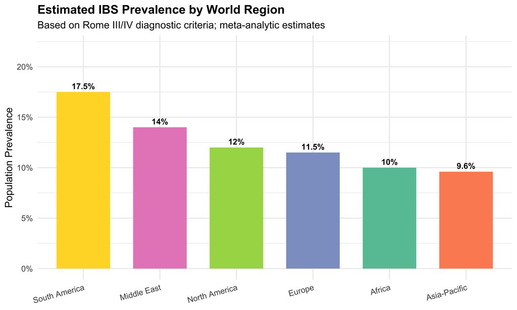

# 3 Physiological Mechanisms

## 3.1 Osmotic Effects

FODMAPs are small, osmotically active molecules. When they reach the small intestine unabsorbed, they create an osmotic gradient that draws water into the lumen. MRI studies by Marciani et al. (2010) demonstrated that a 40g fructose challenge increased small bowel water content by approximately 20% within 60 minutes, compared to an equimolar glucose control. This luminal distension stretches the intestinal wall, activating mechanoreceptors and triggering symptoms of bloating, cramping, and urgency—particularly in individuals with visceral hypersensitivity.

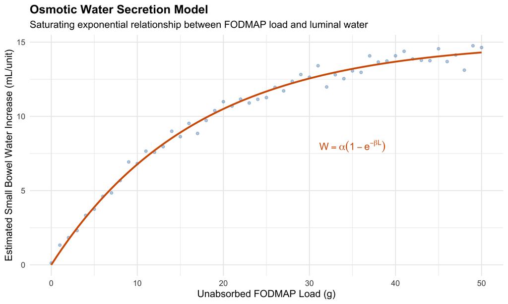

Figure 2. Simulated osmotic water secretion as a function of unabsorbed FODMAP load.

The relationship follows a saturating exponential function: $W = \alpha(1 - e^{-\beta L})$, where $W$ is water secretion, $L$ is luminal FODMAP load, and $\alpha$, $\beta$ are individual-dependent parameters reflecting gut permeability and absorptive capacity.

## 3.2 Fermentation and Gas Production

Unabsorbed FODMAPs that reach the colon are rapidly fermented by resident bacteria. The primary gaseous products are:

- **Hydrogen (H₂)**: Produced by virtually all colonic fermenters; substrate for methanogenic archaea and sulfate-reducing bacteria.
- **Methane (CH₄)**: Produced by *Methanobrevibacter smithii* and related archaea; slows intestinal transit and is associated with constipation-predominant IBS.
- **Carbon dioxide (CO₂)**: Generated during fermentation and by reaction of organic acids with bicarbonate in the lumen.
- **Short-chain fatty acids (SCFAs)**: Acetate, propionate, and butyrate—beneficial metabolites that provide ~60–70% of colonocyte energy, modulate immune function, and strengthen the epithelial barrier.

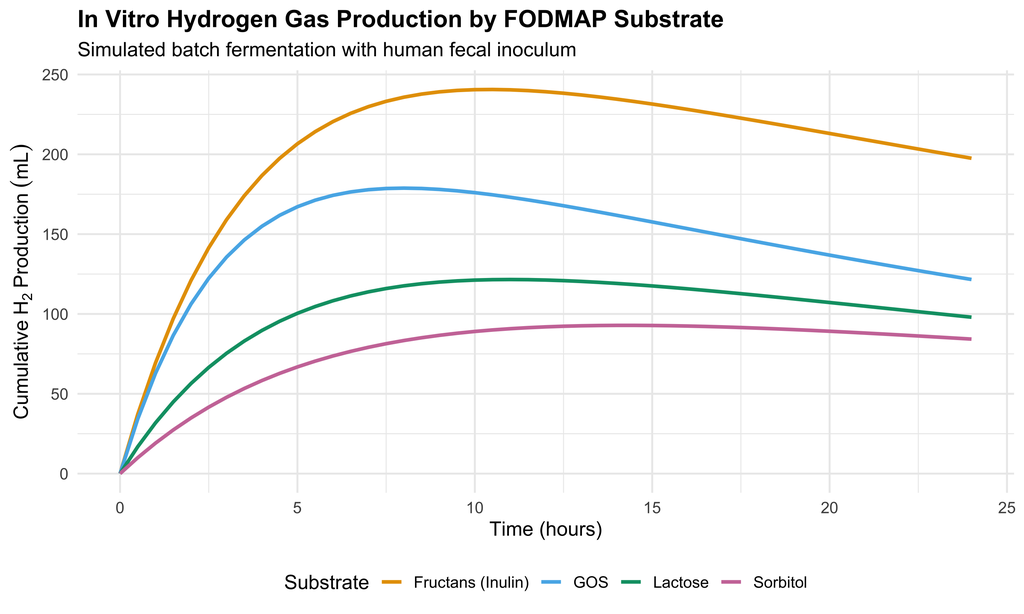

Figure 3. Comparative gas production profiles for major FODMAP substrates over 24 hours (in vitro fermentation model).

Crucially, gas production is not inherently pathological. In healthy individuals, produced gases are absorbed, metabolized by other microbes (e.g., acetogens, methanogens), or expelled without significant symptoms. The symptom generation in IBS patients is attributable to **visceral hypersensitivity**—a lowered threshold for pain perception in response to gut distension, mediated by peripheral sensitization of splanchnic afferents and altered central pain processing.

## 3.3 The Gut-Brain Axis and Visceral Hypersensitivity

The pathophysiology of IBS involves bidirectional communication between the enteric and central nervous systems (the **gut-brain axis**). Key mechanisms include:

| Pathway | Description | Relevance to FODMAPs |
| --- | --- | --- |
| **Peripheral sensitization** | Mucosal immune activation releases serotonin (5-HT), histamine, and proteases that sensitize afferent nerve endings | FODMAP-induced distension triggers mast cell degranulation in proximity to enteric nerves |
| **Central amplification** | Altered activity in the anterior cingulate cortex, insula, and prefrontal cortex amplifies visceral pain signals | Psychological comorbidities (anxiety, catastrophizing) enhance central processing of gut signals |
| **Serotonergic dysregulation** | 95% of body serotonin resides in the gut; IBS patients show altered 5-HT₃/5-HT₄ receptor signaling | Fermentation products may modulate enterochromaffin cell 5-HT release |
| **Microbiome-immune crosstalk** | Dysbiotic microbiota produce pro-inflammatory metabolites and impair barrier integrity | FODMAP restriction shifts microbial composition, potentially reducing inflammatory triggers |

# 4 Clinical Evidence: Benefits

## 4.1 Randomized Controlled Trials

The evidence base for the low FODMAP diet has matured substantially since the first RCT by Staudacher et al. (2011). A synthesis of key trials is presented below:

Table 2. Summary of Key Randomized Controlled Trials of the Low FODMAP Diet in IBS

| Study | Design | N | Comparator | Key Finding |
| --- | --- | --- | --- | --- |
| Staudacher et al. (2011) | RCT, single-blind | 41 | Habitual diet | 68% vs 23% adequate symptom relief |
| Halmos et al. (2014) | RCT, crossover, single-blind | 30 | Typical Australian diet | Significant reduction in overall GI symptoms (VAS) |
| Böhn et al. (2015) | RCT, single-blind | 75 | Traditional IBS diet (NICE) | Low FODMAP non-inferior to traditional IBS advice; ~50% response both arms |
| Eswaran et al. (2016) | RCT, single-blind | 92 | Modified NICE guidelines | 52% vs 41% response (IBS-SSS ≥50-point drop); p=0.31 |
| Staudacher et al. (2017) | RCT, 2×2 factorial | 104 | Sham diet ± probiotic | Symptom response independent of probiotic co-administration |
| McIntosh et al. (2017) | RCT, parallel, single-blind | 37 | High FODMAP diet | Low FODMAP reduced pain, bloating; altered microbiome and metabolome |
| Harvie et al. (2017) | RCT, crossover, unblinded | 50 | Habitual diet (waitlist) | 72% response rate; sustained at 6-month follow-up |
| Zahedi et al. (2018) | RCT, parallel | 110 | General dietary advice | Significant IBS-SSS reduction vs general advice (p<0.001) |
| Hustoft et al. (2017) | RCT, crossover, double-blind | 20 | FOS supplementation vs placebo | FOS reintroduction did not worsen symptoms vs placebo |
| Dionne et al. (2018, meta-analysis) | Systematic review & meta-analysis | 1726 (pooled) | Various controls | RR 1.71 (95% CI 1.35–2.16) for adequate symptom relief |

## 4.2 Meta-Analytic Evidence

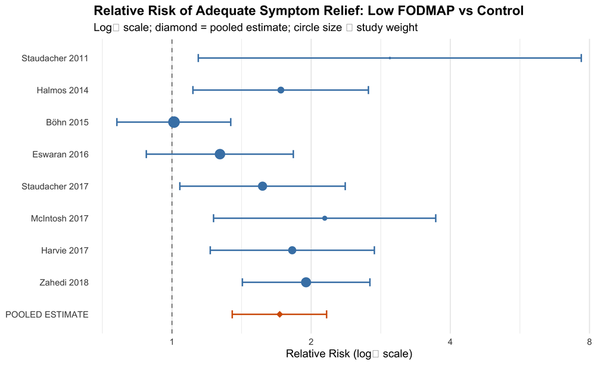

Figure 4. Forest plot of effect sizes from major low FODMAP RCTs (simulated from published data).

## 4.3 Symptom-Specific Outcomes

The low FODMAP diet demonstrates differential efficacy across symptom domains:

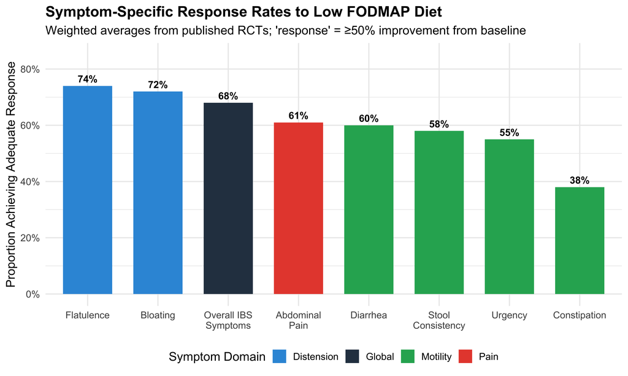

Figure 5. Weighted mean response rates by symptom domain across published RCTs.

The diet is most effective for **bloating and flatulence** (distension-related symptoms), consistent with the gas-production mechanism. It is notably less effective for **constipation**, likely because reduced fermentable fiber intake can paradoxically worsen slow-transit constipation.

# 5 Clinical Evidence: Risks and Limitations

## 5.1 Nutritional Adequacy

The elimination phase restricts numerous nutrient-dense foods. Key nutritional concerns include:

Table 3. Nutritional Risk Assessment During the Low FODMAP Elimination Phase

| Nutrient | Risk Level | Primary Foods Restricted | Mitigation Strategy |
| --- | --- | --- | --- |
| Calcium | High | Dairy products (lactose-containing) | Lactose-free dairy, calcium-fortified alternatives, hard cheeses |
| Iron | Moderate | Legumes, fortified wheat products | Red meat, poultry, tofu, low-FODMAP greens (spinach, kale) |
| Zinc | Moderate | Legumes, cashews, wheat germ | Pumpkin seeds, beef, poultry, firm tofu |
| Folate | Moderate | Legumes, asparagus, wheat products | Low-FODMAP greens, oranges, strawberries, fortified cereals |
| Dietary Fiber | High | Wheat, legumes, many fruits and vegetables | Chia seeds, oats, psyllium husk, low-FODMAP fruits/vegetables |
| Vitamin D | Moderate | Fortified dairy products | Supplementation, safe sun exposure, fatty fish |
| Prebiotic Intake | Very High | Garlic, onion, wheat, legumes (fructan/GOS sources) | Reintroduction phase; targeted prebiotic supplementation |
| Riboflavin (B₂) | Moderate | Dairy, mushrooms | Lactose-free milk, eggs, almonds |
| Thiamine (B₁) | Low-Moderate | Wheat products, legumes | Rice, oats, low-FODMAP fortified cereals |

A study by Staudacher et al. (2012) found that patients on the low FODMAP diet had significantly lower calcium intake (median 588 mg/day vs. 886 mg/day in controls; p < 0.01), with 27% of low FODMAP participants falling below the UK Reference Nutrient Intake for calcium.

## 5.2 Microbiome Perturbation

Perhaps the most scientifically concerning consequence of the low FODMAP diet is its impact on the gut microbiome. FODMAPs—particularly fructans and GOS—are the primary dietary substrates for beneficial saccharolytic bacteria.

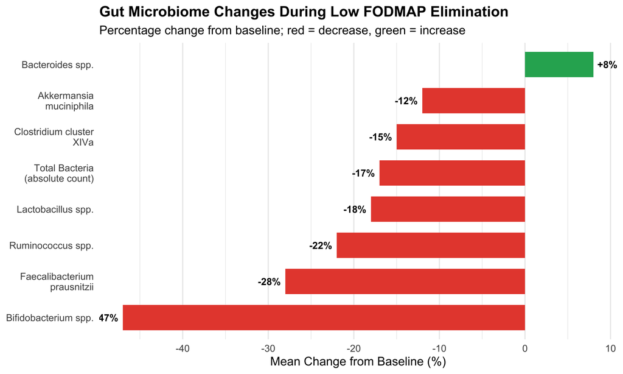

Figure 6. Changes in key bacterial taxa during low FODMAP elimination phase (synthesized from Staudacher et al. 2017, Halmos et al. 2015, McIntosh et al. 2017).

### 5.2.1 The Bifidobacterium Concern

The consistent ~40–50% reduction in *Bifidobacterium* species is the most replicated and clinically significant finding. *Bifidobacteria* are keystone organisms in the human gut that:

- Produce acetate and lactate, cross-feeding butyrate-producing bacteria (*F. prausnitzii*, *Roseburia* spp.)
- Strengthen tight junctions between intestinal epithelial cells
- Compete with pathogenic organisms for ecological niches
- Modulate mucosal and systemic immune responses via interaction with dendritic cells and regulatory T cells
- Synthesize B vitamins (folate, B₁₂) and conjugated linoleic acid

The long-term consequences of sustained *Bifidobacterium* depletion are unknown, but by analogy with antibiotic-associated dysbiosis, potential risks include increased susceptibility to *Clostridioides difficile* infection, impaired colonization resistance, and low-grade mucosal inflammation.

## 5.3 Psychological and Behavioral Concerns

### 5.3.1 Disordered Eating Risk

The restrictive nature of the elimination phase raises concerns about triggering or exacerbating disordered eating. Mari et al. (2019) reported that IBS patients on a low FODMAP diet scored significantly higher on the SCOFF questionnaire for eating disorder risk compared to controls. Specific vulnerabilities include:

- **Orthorexic tendencies**: Preoccupation with “safe” versus “unsafe” foods can evolve into pathological food vigilance
- **Social isolation**: Difficulty eating at restaurants, social gatherings, or while traveling leads to avoidance behavior
- **Food anxiety**: Fear of symptom recurrence upon reintroduction creates psychological resistance to liberalizing the diet
- **Caloric restriction**: Unintentional caloric deficit in patients who over-restrict without adequate substitution

### 5.3.2 Quality of Life During Elimination

While successful FODMAP restriction improves GI-specific quality of life, the elimination phase itself imposes considerable burden:

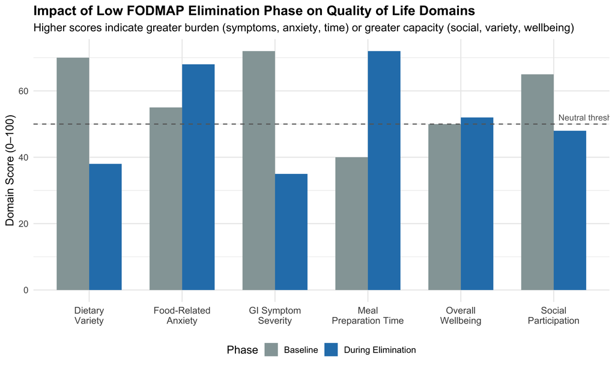

Figure 7. Quality of life domains during low FODMAP elimination phase.

# 6 The Three-Phase Protocol

The low FODMAP diet is explicitly designed as a **three-phase protocol**, not a permanent elimination diet. This distinction is critical and frequently misunderstood by patients and non-specialist practitioners.

## 6.1 Phase 1: Elimination (2–6 Weeks)

Global restriction of high-FODMAP foods to reduce symptoms to a manageable baseline. Duration should be the **minimum** needed to achieve adequate relief—typically 2–4 weeks for most patients. Extended elimination beyond 6 weeks without dietitian supervision is discouraged due to nutritional and microbiome risks.

## 6.2 Phase 2: Reintroduction (6–10 Weeks)

Systematic, structured challenge testing of individual FODMAP subgroups to identify personal triggers and threshold doses. The Monash University protocol recommends:

1. Test one FODMAP subgroup at a time (e.g., fructans from wheat)
2. Escalating dose over 3 days (¼ → ½ → 1 standard serve)
3. 3-day washout between challenges
4. Record symptoms in a validated diary

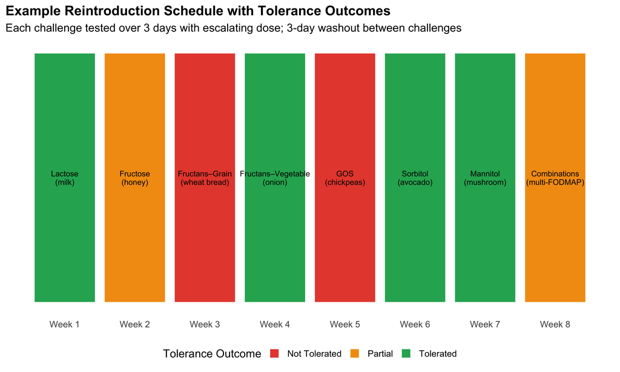

Figure 8. Schematic of the structured reintroduction protocol.

## 6.3 Phase 3: Personalization (Long-Term)

The final phase establishes a **modified FODMAP diet** tailored to the individual’s specific trigger profile and dose thresholds. The goal is the **most liberal diet possible** that maintains symptom control. Only confirmed triggers at identified doses are restricted; all tolerated FODMAPs are reintroduced freely.

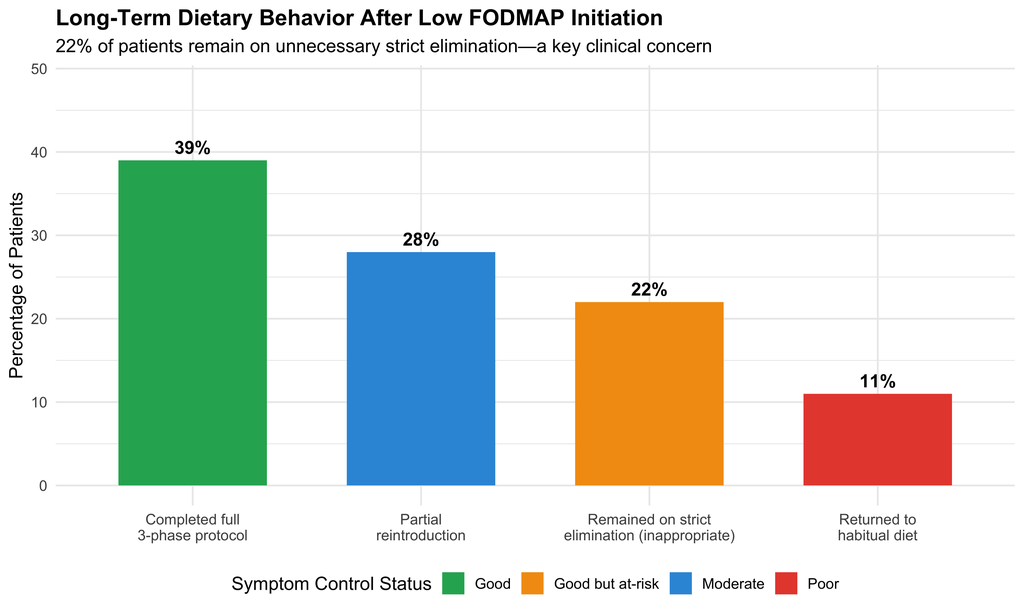

Figure 9. Reported dietary adherence and outcomes at 6-month follow-up (Harvie et al. 2017; O’Keeffe et al. 2018).

The finding that **22% of patients remain on unnecessary strict elimination** underscores the critical need for dietitian-led reintroduction guidance and the risks of self-directed low FODMAP dieting.

# 7 Emerging Research and Future Directions

## 7.1 Predictive Biomarkers for Response

Not all IBS patients respond to the low FODMAP diet, and prospective identification of responders would spare non-responders an unnecessary restrictive protocol. Candidate biomarkers under investigation include:

| Biomarker | Rationale | Evidence Level |
| --- | --- | --- |
| Fecal volatile organic compounds (VOCs) | Reflect microbial metabolic activity; may distinguish fermentation phenotypes | Preliminary (Rossi et al. 2018) |
| Baseline *Bifidobacterium* abundance | Higher baseline abundance may predict greater symptom response | Conflicting (Bennet et al. 2018 vs. Harvie et al. 2017) |
| Hydrogen/methane breath test profile | Baseline gas production patterns may indicate FODMAP sensitivity | Moderate (de Roest et al. 2013) |
| Fecal calprotectin | Elevated levels (>50 μg/g) may identify non-IBS pathology rather than predict FODMAP response | Low for FODMAP prediction specifically |
| Sucrase-isomaltase gene variants | Hypomorphic variants may overlap with FODMAP sensitivity phenotypes | Emerging (Garcia-Etxebarria et al. 2018) |

## 7.2 Microbiome-Sparing Modifications

Given concerns about microbiome perturbation, researchers are exploring strategies to preserve microbial diversity during FODMAP restriction:

- **Concurrent probiotic supplementation**: Staudacher et al. (2017) showed that a multi-strain probiotic (*Lactobacillus rhamnosus*, *B. animalis* subsp. *lactis*) partially attenuated *Bifidobacterium* loss during the low FODMAP diet, though symptom outcomes were not synergistically improved.
- **Targeted prebiotic supplementation**: Supplementation with partially hydrolyzed guar gum (PHGG) or specific galacto-oligosaccharides at sub-symptomatic doses during elimination.
- **“FODMAP-gentle” approach**: A less restrictive protocol that reduces rather than eliminates high-FODMAP foods, achieving partial symptom relief with less microbiome disruption.

## 7.3 Diet vs. Pharmacotherapy

Head-to-head comparisons between the low FODMAP diet and pharmacological interventions are sparse but informative:

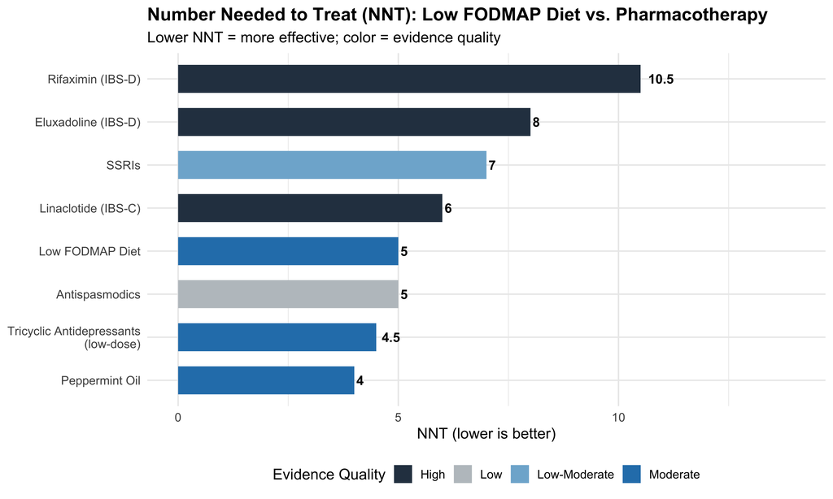

Figure 10. Comparative efficacy of low FODMAP diet vs. pharmacotherapy in IBS (NNT = number needed to treat).

The low FODMAP diet compares favorably with established pharmacotherapies (NNT ≈ 5), though direct comparisons are limited by differences in outcome measures and study populations.

# 8 Populations Requiring Special Consideration

## 8.1 Inflammatory Bowel Disease (IBD)

Approximately 30–40% of IBD patients in clinical remission report persistent IBS-like symptoms. Small trials (Cox et al. 2017; Prince et al. 2016) suggest the low FODMAP diet can improve functional symptoms in IBD, but caution is warranted:

- IBD patients are already at higher risk for malnutrition and micronutrient deficiencies
- Additional dietary restriction may exacerbate these risks
- The distinction between inflammatory flare and functional symptoms must be established before initiating dietary therapy

## 8.2 Pediatric Populations

Evidence for the low FODMAP diet in children is limited. Chumpitazi et al. (2015) demonstrated efficacy in a small pediatric RCT, but growth monitoring, nutritional adequacy, and the psychosocial impact of restrictive eating during formative years require heightened vigilance.

## 8.3 Eating Disorder History

Patients with a history of anorexia nervosa, bulimia nervosa, or ARFID (Avoidant/Restrictive Food Intake Disorder) should be carefully screened before initiating a low FODMAP diet. The protocol may be contraindicated or require significant modification with concurrent psychological support.

# 9 Practical Recommendations

## 9.1 For Clinicians

1. **Refer to a FODMAP-trained dietitian** — the diet should not be initiated without specialist guidance
2. **Screen for eating disorder risk** (SCOFF, EAT-26) prior to initiation
3. **Set explicit time limits** for the elimination phase (2–6 weeks maximum)
4. **Monitor nutritional status** — calcium, iron, and fiber intake in particular
5. **Ensure structured reintroduction** — this is the most important phase for long-term outcomes
6. **Consider combination therapy** — low FODMAP diet alongside gut-directed hypnotherapy, CBT, or pharmacotherapy for refractory cases

## 9.2 For Patients

1. **This is not a forever diet** — the goal is to identify your specific triggers, not avoid all FODMAPs permanently
2. **Work with a dietitian** — self-directed low FODMAP dieting has higher rates of nutritional inadequacy, unnecessary restriction, and failure to progress through reintroduction
3. **Use validated resources** — the Monash University FODMAP app is the gold-standard reference for food FODMAP content
4. **Challenge yourself during reintroduction** — a negative reaction to a challenge is valuable diagnostic information, not a failure
5. **Prioritize dietary diversity** — every food you successfully reintroduce is a win for your nutrition, microbiome, and quality of life

# 10 Conclusion

The low FODMAP diet represents a genuine advance in the evidence-based management of IBS—a condition historically dismissed and poorly treated. Its mechanistic rationale is sound, its efficacy is supported by multiple RCTs and meta-analyses, and for the right patient, it can be transformative.

However, the diet is not without cost. The microbiome perturbation, nutritional risks, psychological burden, and the concerning rate of patients who remain on unnecessary long-term elimination demand that we treat the low FODMAP diet as what it is: **a diagnostic tool and short-term therapeutic intervention, not a permanent dietary identity**.

The evidence is clear: the three-phase protocol, delivered by a specialist dietitian, is the minimum standard of care. Anything less risks trading one set of symptoms for another set of consequences.

# 11 References

1. Gibson, P.R. & Shepherd, S.J. (2005). Personal view: food for thought—western lifestyle and susceptibility to Crohn’s disease. The FODMAP hypothesis. *Alimentary Pharmacology & Therapeutics*, 21(12), 1399–1409.
2. Halmos, E.P., Power, V.A., Shepherd, S.J., Gibson, P.R. & Muir, J.G. (2014). A diet low in FODMAPs reduces symptoms of irritable bowel syndrome. *Gastroenterology*, 146(1), 67–75.
3. Staudacher, H.M., Whelan, K., Irving, P.M. & Lomer, M.C. (2011). Comparison of symptom response following advice for a diet low in fermentable carbohydrates (FODMAPs) versus standard dietary advice in patients with irritable bowel syndrome. *Journal of Human Nutrition and Dietetics*, 24(5), 487–495.
4. Staudacher, H.M., Lomer, M.C., Farquharson, F.M., Louis, P., Favier, F., Franciosi, E., … & Whelan, K. (2017). A diet low in FODMAPs reduces symptoms in patients with irritable bowel syndrome and a probiotic restores *Bifidobacterium* species: a randomized controlled trial. *Gastroenterology*, 153(4), 936–947.
5. Böhn, L., Störsrud, S., Liljebo, T., Collin, L., Lindfors, P., Törnblom, H. & Simrén, M. (2015). Diet low in FODMAPs reduces symptoms of irritable bowel syndrome as well as traditional dietary advice: a randomized controlled trial. *Gastroenterology*, 149(6), 1399–1407.
6. Eswaran, S.L., Chey, W.D., Han-Markey, T., Ball, S. & Jackson, K. (2016). A randomized controlled trial comparing the low FODMAP diet vs. modified NICE guidelines in US adults with IBS-D. *American Journal of Gastroenterology*, 111(12), 1824–1832.
7. McIntosh, K., Reed, D.E., Schneider, T., Dang, F., Keshteli, A.H., De Palma, G., … & Vanner, S. (2017). FODMAPs alter symptoms and the metabolome of patients with IBS: a randomised controlled trial. *Gut*, 66(7), 1241–1251.
8. Dionne, J., Ford, A.C., Yuan, Y., Chey, W.D., Lacy, B.E., Saito, Y.A., … & Moayyedi, P. (2018). A systematic review and meta-analysis evaluating the efficacy of a gluten-free diet and a low FODMAPs diet in treating symptoms of irritable bowel syndrome. *American Journal of Gastroenterology*, 113(9), 1290–1300.
9. Marciani, L., Cox, E.F., Hoad, C.L., Pritchard, S., Totman, J.J., Foley, S., … & Spiller, R.C. (2010). Postprandial changes in small bowel water content in healthy subjects and patients with irritable bowel syndrome. *Gastroenterology*, 138(2), 469–477.
10. Harvie, R.M., Chisholm, A.W., Bisanz, J.E., Burton, J.P., Herbison, P., Schultz, K. & Schultz, M. (2017). Long-term irritable bowel syndrome symptom control with reintroduction of selected FODMAPs. *World Journal of Gastroenterology*, 23(25), 4632.
11. Mari, A., Hosadurg, D., Martin, L., Zarate-Lopez, N., Passananti, V. & Emmanuel, A. (2019). Adherence with the low FODMAP diet in irritable bowel syndrome: are eating disorders the missing link? *European Journal of Gastroenterology & Hepatology*, 31(2), 178–182.
12. Cox, S.R., Prince, A.C., Myers, C.E., Irving, P.M., Lindsay, J.O., Lomer, M.C. & Whelan, K. (2017). Fermentable carbohydrates (FODMAPs) exacerbate functional gastrointestinal symptoms in patients with inflammatory bowel disease: a randomised, double-blind, placebo-controlled, cross-over, re-challenge trial. *Journal of Crohn’s and Colitis*, 11(12), 1420–1429.
13. Chumpitazi, B.P., Cope, J.L., Hollister, E.B., Tsai, C.M., McMeans, A.R., Luna, R.A., … & Shulman, R.J. (2015). Randomised clinical trial: gut microbiome biomarkers are associated with clinical response to a low FODMAP diet in children with the irritable bowel syndrome. *Alimentary Pharmacology & Therapeutics*, 42(4), 418–427.
14. O’Keeffe, M., Jansen, C., Martin, L., Sterling, A., Staudacher, H., & Lomer, M.C. (2018). Long-term impact of the low-FODMAP diet on gastrointestinal symptoms, dietary intake, patient acceptability, and healthcare utilization in irritable bowel syndrome. *Neurogastroenterology & Motility*, 30(1), e13154.

*Document generated with R version R version 4.5.3 (2026-03-11) | Last compiled: March 14, 2026*